# Final Exam

Please answer the following questions. Your code should follow the proper syntax, structure, and style. Your answer should be formatted in the proper units, rounded to two decimal places. All graphs should contain titles, axis names, variable labels, and any formatting that guarantees the graph can be used according to its purpose.

## Q1) Linear Algebra

Solve the system of equations belowusing NumPy's linear algebra function.

\begin{align*} & x + 2y - 3z + 4w = 12 \\ & 2x + 2y - 2z + 3w = 10 \\ & x - y + z - 2w = -4 \\ & y + z = -1 \\ \end{align*}

```python
import numpy as np

A = np.array([[1,2,-3,4], [2,2,-2,3], [1,-1,1,-2], [0,1,1,0]])
C = np.array([12,10,-4,-1])
c = np.linalg.solve(A,C)
print("in the order of x, y, z, w values", c)
```

```
in the order of x, y, z, w values [ 1. -0. -1.  2.]
```

## Q2) Matplotlib

Download and import the data from the following link: https://drive.google.com/file/d/1SjAJuQUY-9UDNGuttMzoFCkaoKY_pxN_/view?usp=sharing(hint: there are column names in the first row of the file)

```python
import pandas as pd
data = pd.read_csv(r"C:\Users\Jae\Desktop\Econ 381\Python calss\midexam\Python Final Data.csv")
df = pd.DataFrame(data)
df
```

|  | season | age | team | games | minutes | FG% | 3P% | FT | FT% | rebounds | points | player | RSorPO |
| --- | --- | --- | --- | --- | --- | --- | --- | --- | --- | --- | --- | --- | --- |
| 0 | 2004 | 19 | CLE | 79 | 39.5 | 0.42 | 0.30 | 5.8 | 0.76 | 5.5 | 20.9 | Lebron James | Regular Season |
| 1 | 2005 | 20 | CLE | 80 | 42.4 | 0.47 | 0.36 | 8.0 | 0.75 | 7.4 | 27.2 | Lebron James | Regular Season |
| 2 | 2006 | 21 | CLE | 79 | 42.5 | 0.48 | 0.33 | 10.3 | 0.74 | 7.0 | 31.4 | Lebron James | Regular Season |
| 3 | 2007 | 22 | CLE | 78 | 40.9 | 0.48 | 0.32 | 9.0 | 0.70 | 6.7 | 27.3 | Lebron James | Regular Season |
| 4 | 2008 | 23 | CLE | 75 | 40.4 | 0.48 | 0.31 | 10.3 | 0.71 | 7.9 | 30.0 | Lebron James | Regular Season |
| ... | ... | ... | ... | ... | ... | ... | ... | ... | ... | ... | ... | ... | ... |
| 87 | 2008 | 29 | LAL | 21 | 41.1 | 0.48 | 0.30 | 9.2 | 0.82 | 5.7 | 30.1 | Kobe Bryant | Playoffs |
| 88 | 2009 | 30 | LAL | 23 | 40.9 | 0.46 | 0.35 | 8.6 | 0.88 | 5.3 | 30.2 | Kobe Bryant | Playoffs |
| 89 | 2010 | 31 | LAL | 23 | 40.1 | 0.46 | 0.37 | 8.0 | 0.84 | 6.0 | 29.2 | Kobe Bryant | Playoffs |
| 90 | 2011 | 32 | LAL | 10 | 35.4 | 0.45 | 0.29 | 6.1 | 0.82 | 3.4 | 22.8 | Kobe Bryant | Playoffs |
| 91 | 2012 | 33 | LAL | 12 | 39.7 | 0.44 | 0.28 | 7.9 | 0.84 | 4.8 | 30.0 | Kobe Bryant | Playoffs |

92 rows × 13 columns

a) Create new separate dataframes for Lebron James, Kobe Bryant, and Michael Jordan. This is to make parts *b-e* easier. The player names are entered as strings in the "player" column of the dataframe.

```python
data_J = []
minutes_J = []
points_J = []
for i in range(0, 29):
    data_J = np.append(data_J, data['player'][i])
    minutes_J = np.append(minutes_J, data['minutes'][i])
    points_J = np.append(points_J, data['points'][i])
df_J = pd.DataFrame({"Name": data_J, "Minutes": minutes_J, "Points": points_J})
df_J
```

|  | Name | Minutes | Points |
| --- | --- | --- | --- |
| 0 | Lebron James | 39.5 | 20.9 |
| 1 | Lebron James | 42.4 | 27.2 |
| 2 | Lebron James | 42.5 | 31.4 |
| 3 | Lebron James | 40.9 | 27.3 |
| 4 | Lebron James | 40.4 | 30.0 |
| 5 | Lebron James | 37.7 | 28.4 |
| 6 | Lebron James | 39.0 | 29.7 |
| 7 | Lebron James | 38.8 | 26.7 |
| 8 | Lebron James | 37.5 | 27.1 |
| 9 | Lebron James | 37.9 | 26.8 |
| 10 | Lebron James | 37.7 | 27.1 |
| 11 | Lebron James | 36.1 | 25.3 |
| 12 | Lebron James | 35.6 | 25.3 |
| 13 | Lebron James | 37.8 | 26.4 |
| 14 | Lebron James | 36.9 | 27.5 |
| 15 | Lebron James | 35.2 | 27.4 |
| 16 | Lebron James | 46.5 | 30.8 |
| 17 | Lebron James | 44.7 | 25.1 |
| 18 | Lebron James | 42.5 | 28.2 |
| 19 | Lebron James | 41.4 | 35.3 |
| 20 | Lebron James | 41.8 | 29.1 |
| 21 | Lebron James | 43.9 | 23.7 |
| 22 | Lebron James | 42.7 | 30.3 |
| 23 | Lebron James | 41.7 | 25.9 |
| 24 | Lebron James | 38.2 | 27.4 |
| 25 | Lebron James | 42.2 | 30.1 |
| 26 | Lebron James | 39.1 | 26.3 |
| 27 | Lebron James | 41.3 | 32.8 |
| 28 | Lebron James | 41.9 | 34.0 |

```python
data_K = []
minutes_K = []
points_K = []
for i in range(29, 57):
    data_K = np.append(data_K, data['player'][i])
    minutes_K = np.append(minutes_K, data['minutes'][i])
    points_K = np.append(points_K, data['points'][i])
df_K = pd.DataFrame({"Name": data_K,"Minutes": minutes_K, "Points": points_K})
df_K
```

|  | Name | Minutes | Points |
| --- | --- | --- | --- |
| 0 | Michael Jordan | 38.3 | 28.2 |
| 1 | Michael Jordan | 25.1 | 22.7 |
| 2 | Michael Jordan | 40.0 | 37.1 |
| 3 | Michael Jordan | 40.4 | 35.0 |
| 4 | Michael Jordan | 40.2 | 32.5 |
| 5 | Michael Jordan | 39.0 | 33.6 |
| 6 | Michael Jordan | 37.0 | 31.5 |
| 7 | Michael Jordan | 38.8 | 30.1 |
| 8 | Michael Jordan | 39.3 | 32.6 |
| 9 | Michael Jordan | 39.3 | 26.9 |
| 10 | Michael Jordan | 37.7 | 30.4 |
| 11 | Michael Jordan | 37.9 | 29.6 |
| 12 | Michael Jordan | 38.8 | 28.7 |
| 13 | Michael Jordan | 34.9 | 22.9 |
| 14 | Michael Jordan | 37.0 | 20.0 |
| 15 | Michael Jordan | 42.8 | 29.3 |
| 16 | Michael Jordan | 45.0 | 43.7 |
| 17 | Michael Jordan | 42.7 | 35.7 |
| 18 | Michael Jordan | 42.7 | 36.3 |
| 19 | Michael Jordan | 42.2 | 34.8 |
| 20 | Michael Jordan | 42.1 | 36.7 |
| 21 | Michael Jordan | 40.5 | 31.1 |
| 22 | Michael Jordan | 41.8 | 34.5 |
| 23 | Michael Jordan | 41.2 | 35.1 |
| 24 | Michael Jordan | 42.0 | 31.5 |
| 25 | Michael Jordan | 40.7 | 30.7 |
| 26 | Michael Jordan | 42.3 | 31.1 |
| 27 | Michael Jordan | 41.5 | 32.4 |

```python
data_M = []
minutes_M = []
points_M = []
for i in range(57,92):
    data_M = np.append(data_M, data['player'][i])
    minutes_M = np.append(minutes_M, data['minutes'][i])
    points_M = np.append(points_M, data['points'][i])
df_M = pd.DataFrame({"Name": data_M, "Minutes": minutes_M, "Points": points_M})
df_M
```

|  | Name | Minutes | Points |
| --- | --- | --- | --- |
| 0 | Kobe Bryant | 15.5 | 7.6 |
| 1 | Kobe Bryant | 26.0 | 15.4 |
| 2 | Kobe Bryant | 37.9 | 19.9 |
| 3 | Kobe Bryant | 38.2 | 22.5 |
| 4 | Kobe Bryant | 40.9 | 28.5 |
| 5 | Kobe Bryant | 38.3 | 25.2 |
| 6 | Kobe Bryant | 41.5 | 30.0 |
| 7 | Kobe Bryant | 37.6 | 24.0 |
| 8 | Kobe Bryant | 40.7 | 27.6 |
| 9 | Kobe Bryant | 41.0 | 35.4 |
| 10 | Kobe Bryant | 40.8 | 31.6 |
| 11 | Kobe Bryant | 38.9 | 28.3 |
| 12 | Kobe Bryant | 36.1 | 26.8 |
| 13 | Kobe Bryant | 38.8 | 27.0 |
| 14 | Kobe Bryant | 33.9 | 25.3 |
| 15 | Kobe Bryant | 38.5 | 27.9 |
| 16 | Kobe Bryant | 38.6 | 27.3 |
| 17 | Kobe Bryant | 29.5 | 13.8 |
| 18 | Kobe Bryant | 34.5 | 22.3 |
| 19 | Kobe Bryant | 28.2 | 17.6 |
| 20 | Kobe Bryant | 14.8 | 8.2 |
| 21 | Kobe Bryant | 20.0 | 8.7 |
| 22 | Kobe Bryant | 39.4 | 19.8 |
| 23 | Kobe Bryant | 39.0 | 21.1 |
| 24 | Kobe Bryant | 43.4 | 29.4 |
| 25 | Kobe Bryant | 43.8 | 26.6 |
| 26 | Kobe Bryant | 44.3 | 32.1 |
| 27 | Kobe Bryant | 44.2 | 24.5 |
| 28 | Kobe Bryant | 44.9 | 27.9 |
| 29 | Kobe Bryant | 43.0 | 32.8 |
| 30 | Kobe Bryant | 41.1 | 30.1 |
| 31 | Kobe Bryant | 40.9 | 30.2 |
| 32 | Kobe Bryant | 40.1 | 29.2 |
| 33 | Kobe Bryant | 35.4 | 22.8 |
| 34 | Kobe Bryant | 39.7 | 30.0 |

b) Now, for each player (James, Bryant, and Jordan) create a scatterplot with points per game (column "points") on the y-axis and minutes played ("minutes") on the x-axis. What can you conclude from the data?

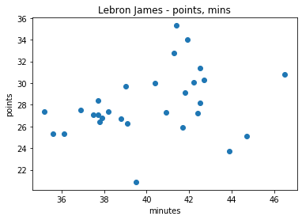

```python
plt.scatter(minutes_J, points_J)
plt.title("Lebron James - points, mins")
plt.ylabel("points")
plt.xlabel("minutes")
plt.show()
```

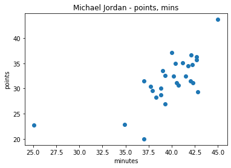

```python
plt.scatter(minutes_K, points_K)
plt.title("Michael Jordan - points, mins")
plt.ylabel("points")
plt.xlabel("minutes")
plt.show()
```

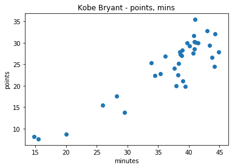

```python
plt.scatter(minutes_M, points_M)
plt.title("Kobe Bryant - points, mins")
plt.ylabel("points")
plt.xlabel("minutes")
plt.show()
```

c) Now create **one** graph that shows the points per game in the regular season ("RSorPO"= "Regular Season") against each player's age in the range 21-29. Is there a player who was a better scorer in their 20s? *Hint: you should end up with one graph with three time series, properly labeled*

```python
data_J = []
minutes_J = []
points_J = []
games_J = []
REG = []
for i in range(0, 11):
    data_J = np.append(data_J, data['player'][i])
    minutes_J = np.append(minutes_J, data['minutes'][i])
    points_J = np.append(points_J, data['points'][i])
    REG = np.append(REG, data['RSorPO'][i])
    games_J = np.append(games_J, data['games'][i])
df_J = pd.DataFrame({"Name": data_J, "Regualr season": REG, "Points": points_J, "Minutes": minutes_J, "Games": games_J})
df_J["Points per game"] = df_J['Points'] / df_J['Games']
df_J
```

|  | Name | Regualr season | Points | Minutes | Games | Points per game |
| --- | --- | --- | --- | --- | --- | --- |
| 0 | Lebron James | Regular Season | 20.9 | 39.5 | 79.0 | 0.264557 |
| 1 | Lebron James | Regular Season | 27.2 | 42.4 | 80.0 | 0.340000 |
| 2 | Lebron James | Regular Season | 31.4 | 42.5 | 79.0 | 0.397468 |
| 3 | Lebron James | Regular Season | 27.3 | 40.9 | 78.0 | 0.350000 |
| 4 | Lebron James | Regular Season | 30.0 | 40.4 | 75.0 | 0.400000 |
| 5 | Lebron James | Regular Season | 28.4 | 37.7 | 81.0 | 0.350617 |
| 6 | Lebron James | Regular Season | 29.7 | 39.0 | 76.0 | 0.390789 |
| 7 | Lebron James | Regular Season | 26.7 | 38.8 | 79.0 | 0.337975 |
| 8 | Lebron James | Regular Season | 27.1 | 37.5 | 62.0 | 0.437097 |
| 9 | Lebron James | Regular Season | 26.8 | 37.9 | 76.0 | 0.352632 |
| 10 | Lebron James | Regular Season | 27.1 | 37.7 | 77.0 | 0.351948 |

```python
data_K = []
minutes_K = []
points_K = []
REG = []
games_K = []
for i in range(29, 38):
    data_K = np.append(data_K, data['player'][i])
    minutes_K = np.append(minutes_K, data['minutes'][i])
    points_K = np.append(points_K, data['points'][i])
    REG = np.append(REG, data['RSorPO'][i])
    games_K = np.append(games_K, data['games'][i])
df_K = pd.DataFrame({"Name": data_K, "Regualr season": REG, "Points": points_K, "Minutes": minutes_K,"Games": games_K})
df_K["Points per game"] = df_K['Points'] / df_K['Games']
df_K
```

|  | Name | Regualr season | Points | Minutes | Games | Points per game |
| --- | --- | --- | --- | --- | --- | --- |
| 0 | Michael Jordan | Regular Season | 28.2 | 38.3 | 82.0 | 0.343902 |
| 1 | Michael Jordan | Regular Season | 22.7 | 25.1 | 18.0 | 1.261111 |
| 2 | Michael Jordan | Regular Season | 37.1 | 40.0 | 82.0 | 0.452439 |
| 3 | Michael Jordan | Regular Season | 35.0 | 40.4 | 82.0 | 0.426829 |
| 4 | Michael Jordan | Regular Season | 32.5 | 40.2 | 81.0 | 0.401235 |
| 5 | Michael Jordan | Regular Season | 33.6 | 39.0 | 82.0 | 0.409756 |
| 6 | Michael Jordan | Regular Season | 31.5 | 37.0 | 82.0 | 0.384146 |
| 7 | Michael Jordan | Regular Season | 30.1 | 38.8 | 80.0 | 0.376250 |
| 8 | Michael Jordan | Regular Season | 32.6 | 39.3 | 78.0 | 0.417949 |

```python
data_M = []
minutes_M = []
points_M = []
REG = []
games_M = []
for i in range(57, 69):
    data_M = np.append(data_M, data['player'][i])
    minutes_M = np.append(minutes_M, data['minutes'][i])
    points_M = np.append(points_M, data['points'][i])
    REG = np.append(REG, data['RSorPO'][i])
    games_M = np.append(games_M, data['games'][i])
df_M = pd.DataFrame({"Name": data_M, "Regualr season": REG, "Points": points_M, "Minutes": minutes_M,"Games": games_M})
df_M["Points per game"] = df_J['Points'] / df_J['Games']
df_M
```

[output not shown]

d) Create **one** scatterplot for the players (James, Bryant, and Jordan) free throw shooting percentage ("FT%") on the y-axis and free throw attempts ("FT") on the x-axis. Make sure that the reader can differentiate between datapoints belonging to each player.

e) Michael Jordan made the playoffs in each of the first 8 years of his career. Compare his performance during the regular season against his performance during the playoffs for these first 8 years of his career. Create **three** graphs, each comparing regular season and playoff data, for points per game ("points"), rebounds per game ("rebounds"), and average field goal percentage ("FG%"). Was Michael Jordan better during the regular season or the playoffs during this time?

## Q3) Building a DataFrame

#### Part a) Building functions with difference equations.

Turn each of these equations into a block or a lambda function. You will be using them throughout the rest of this problem.

Equation 1: $ x_i = x_{i-1}^{9/10} + 500 $

Equation 2: $y_i = y_{i-1}^{10/11} + 200 $

```python
def E1(x):
    return x**(9/10) + 500
def E2(y):
    return y**(10/11) + 200
```

#### Part b) Loops and solutions to diference equations

Starting values:

$ y_0 = 1000$

$x_0 = 2000$

Create three arrays: x, y, and time.

Create a for loop that finds the values for x and y for 50 periods, starting at time period 1.

```python
x0 = [2000]
y0 = [1000]
t = [0]
for i in range(0 ,50):
    t = np.append(t, i+1)
    x0 = np.append(x0, E1(x0[i]))
    y0 = np.append(y0, E2(y0[i]))
print(t)
print(x0)
print(y0)
```

```
[ 0  1  2  3  4  5  6  7  8  9 10 11 12 13 14 15 16 17 18 19 20 21 22 23
 24 25 26 27 28 29 30 31 32 33 34 35 36 37 38 39 40 41 42 43 44 45 46 47
 48 49 50]
[2000.         1435.24844782 1193.80013063 1087.81201632 1040.62791524
 1019.47652256 1009.96398482 1005.67944243 1003.74832529 1002.87766869
 1002.48507279 1002.30803255 1002.22819439 1002.19219007 1002.17595324
 1002.16863091 1002.16532876 1002.16383958 1002.16316801 1002.16286515
 1002.16272857 1002.16266697 1002.16263919 1002.16262667 1002.16262102
 1002.16261847 1002.16261732 1002.1626168  1002.16261657 1002.16261647
 1002.16261642 1002.1626164  1002.16261639 1002.16261638 1002.16261638
 1002.16261638 1002.16261638 1002.16261638 1002.16261638 1002.16261638
 1002.16261638 1002.16261638 1002.16261638 1002.16261638 1002.16261638
 1002.16261638 1002.16261638 1002.16261638 1002.16261638 1002.16261638
 1002.16261638]
[1000.          733.66992312  602.71763748  536.8032497   503.14480066
  485.81468289  476.85095958  472.20326372  469.79031146  468.53672452
  467.88522496  467.54657265  467.37052279  467.27899792  467.23141471
  467.20667615  467.19381446  467.18712759  467.18365103  467.18184354
  467.18090381  467.18041524  467.18016123  467.18002916  467.1799605
  467.1799248   467.17990625  467.1798966   467.17989158  467.17988897
  467.17988762  467.17988691  467.17988654  467.17988635  467.17988625
  467.1798862   467.17988618  467.17988616  467.17988615  467.17988615
  467.17988615  467.17988615  467.17988615  467.17988615  467.17988615
  467.17988615  467.17988615  467.17988615  467.17988615  467.17988615
  467.17988615]
```

#### Part c) DataFrame

Using the three arrays you created in the previous section, create a DataFrame with columns 3 columns for time, x, and y. Make sure you name the columns accordingly.

```python
import pandas as pd
data = pd.DataFrame({'Time': t, 'x': x0, 'y': y0})
data
```

|  | Time | x | y |
| --- | --- | --- | --- |
| 0 | 0 | 2000.000000 | 1000.000000 |
| 1 | 1 | 1435.248448 | 733.669923 |
| 2 | 2 | 1193.800131 | 602.717637 |
| 3 | 3 | 1087.812016 | 536.803250 |
| 4 | 4 | 1040.627915 | 503.144801 |
| 5 | 5 | 1019.476523 | 485.814683 |
| 6 | 6 | 1009.963985 | 476.850960 |
| 7 | 7 | 1005.679442 | 472.203264 |
| 8 | 8 | 1003.748325 | 469.790311 |
| 9 | 9 | 1002.877669 | 468.536725 |
| 10 | 10 | 1002.485073 | 467.885225 |
| 11 | 11 | 1002.308033 | 467.546573 |
| 12 | 12 | 1002.228194 | 467.370523 |
| 13 | 13 | 1002.192190 | 467.278998 |
| 14 | 14 | 1002.175953 | 467.231415 |
| 15 | 15 | 1002.168631 | 467.206676 |
| 16 | 16 | 1002.165329 | 467.193814 |
| 17 | 17 | 1002.163840 | 467.187128 |
| 18 | 18 | 1002.163168 | 467.183651 |
| 19 | 19 | 1002.162865 | 467.181844 |
| 20 | 20 | 1002.162729 | 467.180904 |
| 21 | 21 | 1002.162667 | 467.180415 |
| 22 | 22 | 1002.162639 | 467.180161 |
| 23 | 23 | 1002.162627 | 467.180029 |
| 24 | 24 | 1002.162621 | 467.179961 |
| 25 | 25 | 1002.162618 | 467.179925 |
| 26 | 26 | 1002.162617 | 467.179906 |
| 27 | 27 | 1002.162617 | 467.179897 |
| 28 | 28 | 1002.162617 | 467.179892 |
| 29 | 29 | 1002.162616 | 467.179889 |
| 30 | 30 | 1002.162616 | 467.179888 |
| 31 | 31 | 1002.162616 | 467.179887 |
| 32 | 32 | 1002.162616 | 467.179887 |
| 33 | 33 | 1002.162616 | 467.179886 |
| 34 | 34 | 1002.162616 | 467.179886 |
| 35 | 35 | 1002.162616 | 467.179886 |
| 36 | 36 | 1002.162616 | 467.179886 |
| 37 | 37 | 1002.162616 | 467.179886 |
| 38 | 38 | 1002.162616 | 467.179886 |
| 39 | 39 | 1002.162616 | 467.179886 |
| 40 | 40 | 1002.162616 | 467.179886 |
| 41 | 41 | 1002.162616 | 467.179886 |
| 42 | 42 | 1002.162616 | 467.179886 |
| 43 | 43 | 1002.162616 | 467.179886 |
| 44 | 44 | 1002.162616 | 467.179886 |
| 45 | 45 | 1002.162616 | 467.179886 |
| 46 | 46 | 1002.162616 | 467.179886 |
| 47 | 47 | 1002.162616 | 467.179886 |
| 48 | 48 | 1002.162616 | 467.179886 |
| 49 | 49 | 1002.162616 | 467.179886 |
| 50 | 50 | 1002.162616 | 467.179886 |

#### Part d) Plotting

Plot the arrays on the same graph with time on the x axis and the functions on the y axis. Format the graph to look like the one below.

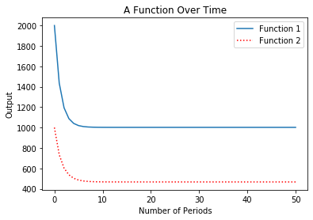

```python
import matplotlib.pyplot as plt

plt.plot(t, x0, label = 'Function 1')
plt.plot(t, y0, ':', color = 'red', label = 'Function 2')
plt.title("A Function Over Time")
plt.ylabel("Output")
plt.xlabel("Number of Periods")
plt.legend()
plt.show()
```

## Q4) Inflation

The inflation rates in China from the years 2012 to 2016 are as follows:

| Year | Inflation Rate (Percent) |
| --- | --- |
| 2012 | 2.643051771 |
| 2013 | 2.62808601 |
| 2014 | 2.00034488 |
| 2015 | 1.437024514 |
| 2016 | 2.0 |

Suppose you wanted to find the average inflation rate over the five years in the data. You can't just take the average of the values in the data, inflation rates afffect the value of the price index as time goes by, compounding on each other. To find the average inflation rate over five years we need the level of the price index that generated the inflation data. To do this, you would need to convert each year to an index. 2012 will become 100 because that is easiest. Then you will multiply 100 by 1 + the inflation rate in 2013 to get 2013's index. Next, you will multiply 2013's index by 1 + 2014's inflation rate to get 2014's index, and so on. See the table below for a demonstration.

| Year | Inflation Rate (Percent) | Equation | Index |
| --- | --- | --- | --- |
| 2012 | 2.64 | N/A | 100 |
| 2013 | 2.63 | $ 1.0263 * 100$ | 102.63 |
| 2014 | 2.0 | $1.02 * 102.63$ | 104.68 |
| 2015 | 1.44 | $1.0144 * 104.68$ | 106.19 |
| 2016 | 2.0 | $1.02 * 106.19$ | 108.31 |

After you have converted each year to an index, you need to calculate the average rate using the following formula:

Below is the code that does this process manually. Your job is to convert it to a loop. Convert all the rates to indices inside the loop, then calculate the average and print your answer outside of the loop. You should have two identical answers, one from the code already written, and one that you created.

```python
ChinaInflation = np.array([2.643051771, 2.62808601, 2.000344887, 1.437024514, 2.0])

#Creating Indices
twelve = 100
thirteen = (1 + (ChinaInflation[-4]/100)) * twelve
fourteen = (1 + (ChinaInflation[-3]/100)) * thirteen
fifteen = (1 + (ChinaInflation[-2]/100)) * fourteen
sixteen = (1 + (ChinaInflation[-1]/100)) * fifteen

#Finding average and printing
average = (((sixteen/twelve) ** (1/5)) - 1)
print('{:.2%}'.format(average))

#Create a loop to find the indices
inf = [100]
for i in range(0, 4):
    i += 1
    inf = np.append(inf, (1 + (ChinaInflation[i]/100)) * inf[i - 1])
print(inf)

#Find the average and print
avg_inf = (inf[4]/inf[0])**(1/5) - 1
print('{:.2%}'.format(avg_inf))
```

```
1.61%
[100.         102.62808601 104.68100168 106.18529334 108.3089992 ]
1.61%
```